# R Notebook

http://www.bodowinter.com/tutorial/bw_LME_tutorial1.pdf

### A Simple Example: Linear Regression

| sex | pitch |
| --- | --- |
| female | 233 |
| female | 204 |
| female | 242 |
| male | 130 |
| male | 112 |
| male | 142 |

```r
summary(xmdl)
```

```
Call:
lm(formula = pitch ~ sex, data = my.df)

Residuals:
      1       2       3       4       5       6
  6.667 -22.333  15.667   2.000 -16.000  14.000

Coefficients:
            Estimate Std. Error t value Pr(>|t|)
(Intercept)   226.33      10.18  22.224 2.43e-05 ***
sexmale       -98.33      14.40  -6.827  0.00241 **
---
Signif. codes:  0 ‘***’ 0.001 ‘**’ 0.01 ‘*’ 0.05 ‘.’ 0.1 ‘ ’ 1

Residual standard error: 17.64 on 4 degrees of freedom
Multiple R-squared:  0.921, Adjusted R-squared:  0.9012
F-statistic: 46.61 on 1 and 4 DF,  p-value: 0.002407
```

#### Interpreting R-squared and significance

The Multiple R-squared in the output is the is a measure of “variance explained”.  
*In this case, we can that 92.1% of the variance in pitch is accounted for in our model.* Next, looking at the p-value line, we see the model is statistically significant. The p-value is a conditional probability, it is a probability under the condition that the null hypothesis is true. In this case, the null hypothesis is “sex has no effect on pitch”. So we can interpret this as saying that our data would only have 0.2% likelihood of corring if sex does not predict pitch.  
*We constructed a linear model of pitch as a function of sex. This model was significant (F(1,4)=46.61, p<0.01).*

#### Interpreting Coefficients

The coefficient for the intercept is ~226, and for “sexmale” is~ -98. What do these mean? Because of the way the linear model works, the first value, the intercept, is an estimate of the mean of the female category. This can be verifified by finding the mean pitch for females

```r
meanFemale = mean(my.df[my.df$sex=="female",]$pitch)
meanFemale
```

```
[1] 226.3333
```

```r
meanMale = mean(my.df[my.df$sex=="male",]$pitch)
meanMale
```

```
[1] 128
```

```r
meanMale - meanFemale
```

```
[1] -98.33333
```

Sure enough, we see that the intercept coefficient is the mean pitch for females, and the coefficient for “sexmale” is the difference between the mean for females and males. To sum up, the estimate for “(Intercept)” is the estimate for the female category,  
and the estimate for “sexmale” is the estimate for the difference between the females and the male category.

#### Interpreting p values for coefficients

The p-values to the right of this table correspond to tests whether each coefficient is “nonzero”. Obviously, 226.33 Hz is different from zero, so the intercept is “significant” with a very low p-value. The slope -98.33 is also different from zero (but in the negative direction), and so this is significant as well.

### Centering the Data

Setup another data set with age and pitch, and create a linear model for it

```r
age = c(14,23,35,48,52,67)
pitch = c(252,244,240,233,212,204)
my.df = data.frame(age,pitch)
xmdl = lm(pitch ~ age, my.df)
summary(xmdl)
```

```
Call:
lm(formula = pitch ~ age, data = my.df)

Residuals:
     1      2      3      4      5      6
-2.338 -2.149  4.769  9.597 -7.763 -2.115

Coefficients:
            Estimate Std. Error t value Pr(>|t|)
(Intercept) 267.0765     6.8522   38.98 2.59e-06 ***
age          -0.9099     0.1569   -5.80  0.00439 **
---
Signif. codes:  0 ‘***’ 0.001 ‘**’ 0.01 ‘*’ 0.05 ‘.’ 0.1 ‘ ’ 1

Residual standard error: 6.886 on 4 degrees of freedom
Multiple R-squared:  0.8937,    Adjusted R-squared:  0.8672
F-statistic: 33.64 on 1 and 4 DF,  p-value: 0.004395
```

In this case, the intercept is not meaningful to us, because it predicts the value of pitch at age 0. Instead, let’s “center” the data so that the intercept predicts pitch at the average age of the data set

```r
my.df$age.c = my.df$age - mean(my.df$age)
xmdl = lm(pitch ~ age.c, my.df)
summary(xmdl)
```

```
Call:
lm(formula = pitch ~ age.c, data = my.df)

Residuals:
     1      2      3      4      5      6
-2.338 -2.149  4.769  9.597 -7.763 -2.115

Coefficients:
            Estimate Std. Error t value Pr(>|t|)
(Intercept) 230.8333     2.8113   82.11 1.32e-07 ***
age.c        -0.9099     0.1569   -5.80  0.00439 **
---
Signif. codes:  0 ‘***’ 0.001 ‘**’ 0.01 ‘*’ 0.05 ‘.’ 0.1 ‘ ’ 1

Residual standard error: 6.886 on 4 degrees of freedom
Multiple R-squared:  0.8937,    Adjusted R-squared:  0.8672
F-statistic: 33.64 on 1 and 4 DF,  p-value: 0.004395
```

Here, the intercept is a prediction of the pitch at the average age, and the age.c coefficient is how much the prediction changes for each increase in age. Pitch decreases by -.90 Hz for every year of age.

### Assumptions

#### (1) Linearity

It’s called “linear model” for a reason; the thing we are predicting has to be the result of a *linear combination* of our formula. (predicted variable = bx + b + e(error) If it doesn’t, the residual plot will indicate some kind of curve, or it will indicate some other pattern (e.g., two lines if you have categorical binary data)

To check this, we can construct a rediduals plot.

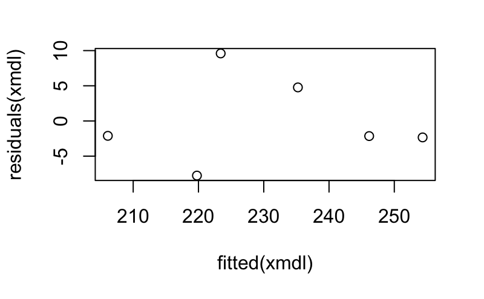

```r
plot(fitted(xmdl),residuals(xmdl))
```

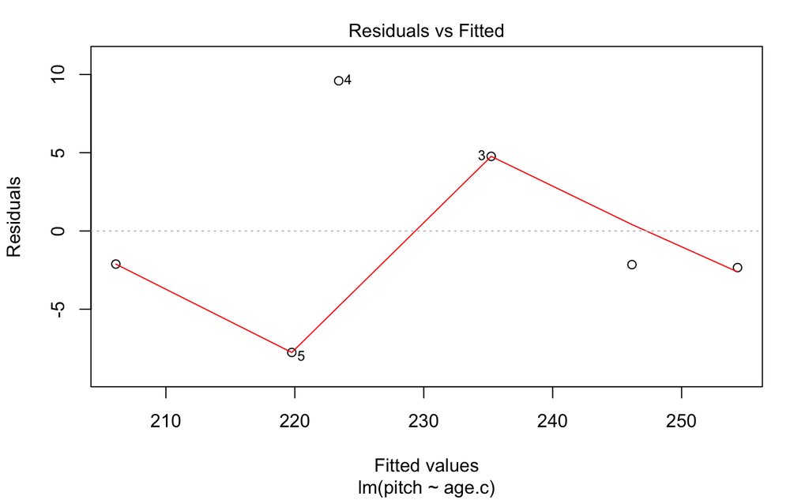

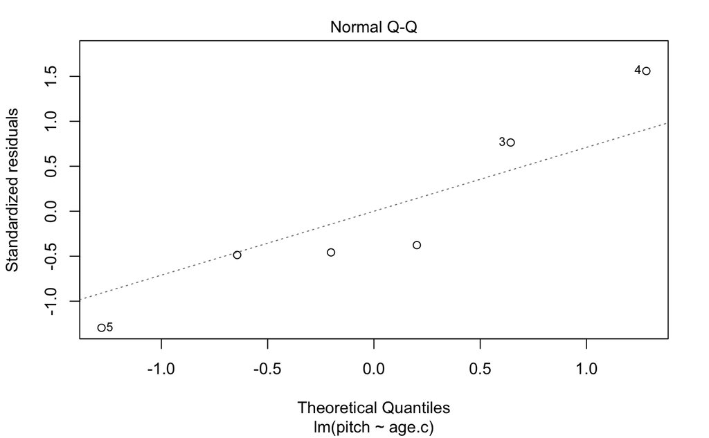

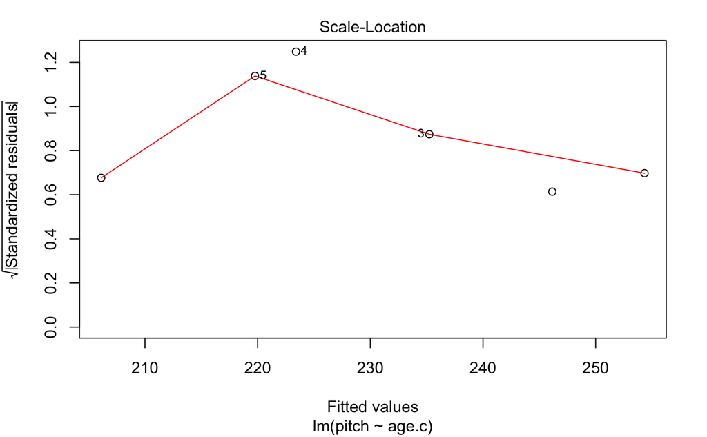

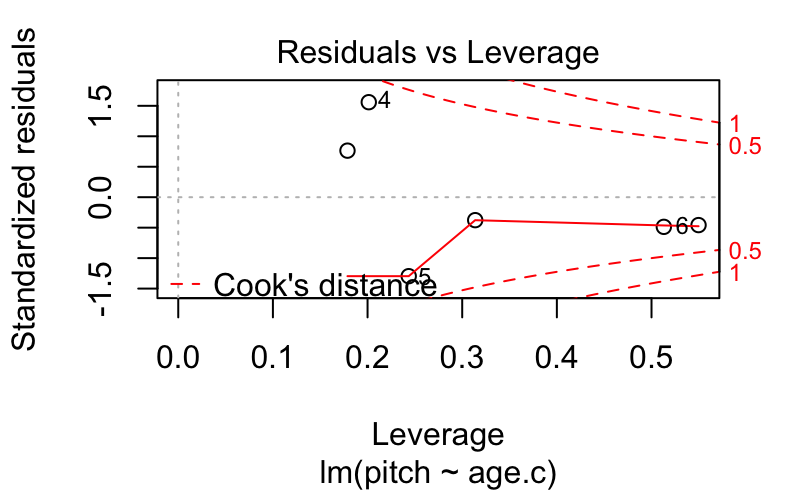

```r
plot(xmdl)
```

Looking at the first plot, the model prediction is the horizonatal line at 0. We see no obvious pattern emerge. Alternatively, if the residuals made a curve, or were in stripes, then we would supsect that perhaps the a linear model was not the best fit and we would either need to turn to log transforms for other methods.

…continue to follow http://www.bodowinter.com/tutorial/bw_LME_tutorial1.pdf for more information on residuals and checking assumptions